# Predictive Analytics for Transfusion Need

## Setup

This notebook connects to a local MySQL database (`BloodMatching`) containing patient, vitals, and lab tables. Credentials are loaded from a `.env` file (not committed to version control — see `.gitignore`) rather than hardcoded, so this notebook can be shared publicly without exposing database access.

To run this notebook yourself: create a `.env` file in this directory with `DB_HOST`, `DB_USER`, `DB_PASSWORD`, and `DB_NAME`.

## Project Overview

A **small-data ML pipeline predicting blood transfusion need** from routine patient vitals (heart rate, respiratory rate, oxygen saturation, blood pressure, sex) — built on a 206-row MIMIC-style demo dataset (14 positive cases)

**Pipeline:** SQL ingestion → data cleaning & aggregation → leakage-safe feature selection → SMOTE-balanced cross-validation (Random Forest vs. Logistic Regression) → threshold & calibration analysis → client-side model deployment.

## Dataset

The **Medical Information Mart for Intensive Care (MIMIC)-IV** database is comprised of deidentified electronic health records for patients admitted to the Beth Israel Deaconess Medical Center https://physionet.org/content/mimic-iv-demo/2.2/

| Attribute | Value |
| --- | --- |
| Total rows (patient stays) | 206 |
| Positive cases (`needs_transfusion = 1`) | 14 (~6.8%) |
| Negative cases | 192 (~93.2%) |
| Features used in final model | 6 |
| Source tables | `patients`, `vital`, `lab_result` |
| Database | MySQL (`BloodMatching`) |

### Features(6, after leakage removal)

| Feature | Description | Type |
| --- | --- | --- |
| Gender | Patient sex, label-encoded | Categorical |
| heart_rate_mean | Mean heart rate across the stay | Continuous |
| resprate_mean | Mean respiratory rate across the stay | Continuous |
| o2sat_mean | Mean oxygen saturation across the stay | Continuous |
| sbp_mean | Mean systolic blood pressure across the stay | Continuous |
| dbp_mean | Mean diastolic blood pressure across the stay | Continuous |

### Target

needs_transfusion is a rule-derived synthetic label (hemoglobin < 7.5 OR (sbp_min < 90 AND heart_rate_max > 100)), not a real clinical transfusion-order event.

hemoglobin, sbp_min, and heart_rate_max are excluded from the feature set since they directly define the label.

## Methodology

- **Ingestion** — patients, vitals, and lab data loaded into a local MySQL database via SQLAlchemy, credentials handled through environment variables.
- **Cleaning & aggregation** — vitals aggregated from repeated per-reading rows to one row per stay (fixing a many-to-many join bug in the process); numeric coercion, sentinel-value handling, and median imputation for missing values.
- **Leakage-safe feature selection** — label-defining columns and everything derived from them excluded from X, after two separate rounds of leakage were traced and fixed.
- **Class imbalance handling** — SMOTE applied inside each cross-validation fold via an imblearn.Pipeline, avoiding synthetic-sample leakage across folds.
- **Model comparison** — Random Forest vs. Logistic Regression, both evaluated on identical stratified 5-fold splits, reporting mean ROC-AUC ± standard deviation rather than a single score.
- **Threshold & calibration** — out-of-fold probabilities used to select an operating threshold via precision-recall curve (favoring recall, since missing a transfusion need is costlier than a false alarm), with a calibration curve checking whether predicted probabilities are trustworthy.
- **Deployment** — final model refit on the full dataset, exported to JavaScript via m2cgen, running entirely client-side in the interactive demo.

## Key Findings

[output not shown]

```python
import sys
import pandas as pd
from sqlalchemy import create_engine
import numpy as np
import mysql.connector as db
import os
import matplotlib.pyplot as plt
import seaborn as sns
import plotly.graph_objects as go
from plotly.subplots import make_subplots
from dotenv import load_dotenv
from sklearn.preprocessing import LabelEncoder
from sklearn.model_selection import train_test_split
from sklearn.ensemble import RandomForestClassifier
from sklearn.linear_model import LogisticRegression
from sklearn.metrics import classification_report, confusion_matrix, roc_auc_score , precision_recall_curve
from sklearn.model_selection import StratifiedKFold, cross_val_score , cross_val_predict
from sklearn.calibration import calibration_curve
from imblearn.over_sampling import SMOTE
from imblearn.pipeline import Pipeline as ImbPipeline
import m2cgen as m2c
```

```python
print(os.getcwd())
print(sys.executable)
```

```
/Users/samikshatripathy/Data Science/blood Transfusion
/opt/miniconda3/envs/my-conda-env/bin/python
```

```python
found = load_dotenv()
print('Loaded:',found)
```

```
Loaded: True
```

```python
import os
from dotenv import load_dotenv

load_dotenv()  # reads the .env file into environment variables

con = db.connect(
    host=os.getenv("DB_HOST"),
    user=os.getenv("DB_USER"),
    password=os.getenv("DB_PASSWORD"),
    database=os.getenv("DB_NAME")
)

engine = create_engine(
    f'mysql+mysqlconnector://{os.getenv("DB_USER")}:{os.getenv("DB_PASSWORD")}@{os.getenv("DB_HOST")}/{os.getenv("DB_NAME")}'
)
```

## Data Ingestion

Source data (`patients.csv`, vitals, lab values) is loaded into a local MySQL database. Tables are written with `if_exists='replace'` rather than `'append'` — this makes re-running the notebook idempotent.

An earlier version of this pipeline used `'append'`, which silently duplicated rows on every re-run and inflated the dataset from ~222 patients to over 2 million rows before this was caught and fixed.

```python
df_patients = pd.read_csv(r'/Users/samikshatripathy/Downloads/patients (1).csv')
df_patients = pd.DataFrame(df_patients)
df_patients.head()
```

|  | subject_id | hadm_id | stay_id | intime | outtime | gender | race | arrival_transport | disposition |
| --- | --- | --- | --- | --- | --- | --- | --- | --- | --- |
| 0 | 10014729 | 23300884.0 | 37887480 | 3/19/2125 12:36 | 3/19/2125 16:59 | F | WHITE - OTHER EUROPEAN | WALK IN | ADMITTED |
| 1 | 10018328 | 26706939.0 | 34176810 | 02/05/54 17:09 | 02/05/54 22:54 | F | WHITE | AMBULANCE | ADMITTED |
| 2 | 10018328 | NaN | 32103106 | 08/03/54 15:31 | 08/03/54 22:29 | F | WHITE | AMBULANCE | HOME |
| 3 | 10020640 | 27984218.0 | 38797992 | 02/12/53 21:59 | 2/13/2153 1:38 | F | WHITE | AMBULANCE | ADMITTED |
| 4 | 10015272 | 27993466.0 | 33473053 | 06/12/37 16:54 | 06/12/37 18:37 | F | WHITE | AMBULANCE | ADMITTED |

```python
df_patients = df_patients[['subject_id', 'stay_id','gender','race','intime']]
df_patients['intime'] = pd.to_datetime(df_patients['intime'], format='mixed')
df_patients.to_sql('patients',con = engine,if_exists = 'replace',index = False)
```

```
222
```

```python
print(df_patients.shape)
print(df_patients['subject_id'].nunique())
print(df_patients['stay_id'].nunique())
dupe_ids = df_patients[df_patients.duplicated('subject_id', keep=False)]
print(dupe_ids.sort_values('subject_id').head(20))
```

```
(222, 5)
64
222
     subject_id   stay_id gender                    race              intime
38     10000032  33258284      F                   WHITE 1980-05-06 19:17:00
40     10000032  32952584      F                   WHITE 2180-07-22 16:24:00
41     10000032  38112554      F                   WHITE 2180-06-26 15:54:00
42     10000032  35968195      F                   WHITE 1980-08-05 20:58:00
39     10000032  39399961      F                   WHITE 2180-07-23 05:54:00
9      10001217  39866888      F                   WHITE 2157-11-18 17:38:00
10     10001217  39300221      F                   WHITE 2157-11-29 19:28:00
121    10002428  32822973      F                   WHITE 2156-04-30 18:30:00
120    10002428  37376268      F                   WHITE 2160-04-14 09:01:00
119    10002428  38216551      F                   WHITE 2160-07-15 17:34:00
118    10002428  33227245      F                   WHITE 2055-12-04 18:34:00
117    10002428  33978784      F                   WHITE 2056-05-11 11:29:00
116    10002428  32007337      F                   WHITE 2056-04-12 09:56:00
115    10002428  34982171      F                   WHITE 2157-07-16 01:50:00
102    10002930  32272346      F  BLACK/AFRICAN AMERICAN 2000-06-04 16:38:00
103    10002930  31579293      F  BLACK/AFRICAN AMERICAN 2196-04-14 05:55:00
108    10002930  35114287      F  BLACK/AFRICAN AMERICAN 2199-02-17 14:32:00
105    10002930  30193781      F  BLACK/AFRICAN AMERICAN 2198-04-17 11:42:00
107    10002930  35540249      F  BLACK/AFRICAN AMERICAN 2197-04-16 22:57:00
109    10002930  39910144      F  BLACK/AFRICAN AMERICAN 2001-02-12 15:11:00
```

```python
df_patients.info()
```

```
<class 'pandas.DataFrame'>
RangeIndex: 222 entries, 0 to 221
Data columns (total 5 columns):
 #   Column      Non-Null Count  Dtype
---  ------      --------------  -----
 0   subject_id  222 non-null    int64
 1   stay_id     222 non-null    int64
 2   gender      222 non-null    str
 3   race        222 non-null    str
 4   intime      222 non-null    datetime64[us]
dtypes: datetime64[us](1), int64(2), str(2)
memory usage: 8.8 KB
```

```python
df_vitals = pd.read_csv(r"/Users/samikshatripathy/Downloads/vital_sign.csv")
df_vitals = pd.DataFrame(df_vitals)
df_vitals = df_vitals.rename(columns={"heartrate": "heart_rate"})
df_vitals.head()
```

|  | subject_id | stay_id | charttime | temperature | heart_rate | resprate | o2sat | sbp | dbp | rhythm | pain |
| --- | --- | --- | --- | --- | --- | --- | --- | --- | --- | --- | --- |
| 0 | 10014729 | 37887480 | 3/19/2125 13:22 | NaN | 124.0 | 24.0 | 100.0 | 93.0 | 65.0 | NaN | NaN |
| 1 | 10014729 | 37887480 | 3/19/2125 18:28 | 98.9 | 106.0 | 18.0 | 100.0 | 115.0 | 70.0 | Sinus Tachycardia | 5 |
| 2 | 10014729 | 37887480 | 3/19/2125 13:07 | NaN | 128.0 | 18.0 | 100.0 | 132.0 | 96.0 | Sinus Tachycardia | NaN |
| 3 | 10014729 | 37887480 | 3/19/2125 16:23 | 99.8 | 115.0 | 22.0 | 97.0 | 114.0 | 45.0 | Sinus Tachycardia | 0 |
| 4 | 10014729 | 37887480 | 3/19/2125 13:24 | NaN | 125.0 | NaN | NaN | NaN | NaN | NaN | NaN |

```python
df_vitals.info
```

```
<bound method DataFrame.info of       subject_id   stay_id        charttime  temperature  heart_rate  \
0       10014729  37887480  3/19/2125 13:22          NaN       124.0
1       10014729  37887480  3/19/2125 18:28         98.9       106.0
2       10014729  37887480  3/19/2125 13:07          NaN       128.0
3       10014729  37887480  3/19/2125 16:23         99.8       115.0
4       10014729  37887480  3/19/2125 13:24          NaN       125.0
...          ...       ...              ...          ...         ...
1033    10002428  32822973  4/30/2156 18:47          NaN       100.0
1034    10002428  32822973  4/30/2156 20:14          NaN        90.0
1035    10002428  32822973  4/30/2156 19:47          NaN        96.0
1036    10002428  33227245  12/4/2155 21:31         97.4        82.0
1037    10002428  33227245  12/4/2155 21:36         97.4        82.0

      resprate  o2sat    sbp   dbp             rhythm pain
0         24.0  100.0   93.0  65.0                NaN  NaN
1         18.0  100.0  115.0  70.0  Sinus Tachycardia    5
2         18.0  100.0  132.0  96.0  Sinus Tachycardia  NaN
3         22.0   97.0  114.0  45.0  Sinus Tachycardia    0
4          NaN    NaN    NaN   NaN                NaN  NaN
...        ...    ...    ...   ...                ...  ...
1033      30.0   98.0  100.0  55.0                NaN    0
1034      26.0    NaN   80.0  41.0                NaN    0
1035      29.0    NaN  104.0  56.0                NaN    0
1036      16.0  100.0  148.0  85.0                NaN  NaN
1037      18.0  100.0  148.0  75.0                NaN    0

[1038 rows x 11 columns]>
```

## Why vitals are aggregated to one row per stay

`stay_id` is a primary key in `patients` (one row per stay) but a foreign key in `vital`, where it legitimately repeats — one row per vitals reading, several readings per stay. That's normal relational structure.

The bug: `lab_result` was originally built by copying `vital`'s row structure directly, giving it the same one-to-many repetition. When the view joined two tables that were *both* one-to-many against the same `stay_id`, SQL paired every matching row on both sides — a many-to-many join that multiplied ~222 patients into millions of nonsensical rows (a vitals reading from 2am paired with a lab value that was really copied from an unrelated 6pm reading).

**Fix:** both `vital` and `lab_result` are aggregated to exactly one row per `stay_id` before the join, so each row in the final dataset represents one genuine patient encounter — which is also the right unit for this prediction task in the first place.

```python
df_vitals_agg = df_vitals.groupby('stay_id').agg(
    heart_rate_mean=('heart_rate', 'mean'),
    heart_rate_max=('heart_rate', 'max'),
    resprate_mean=('resprate', 'mean'),
    o2sat_mean=('o2sat', 'mean'),
    sbp_mean=('sbp', 'mean'),
    sbp_min=('sbp', 'min'),
    dbp_mean=('dbp', 'mean')
).reset_index()

print(df_vitals_agg.shape)
print(df_vitals_agg.columns.tolist())
```

```
(206, 8)
['stay_id', 'heart_rate_mean', 'heart_rate_max', 'resprate_mean', 'o2sat_mean', 'sbp_mean', 'sbp_min', 'dbp_mean']
```

```python
df_vitals_agg.to_sql("vital",con=engine,if_exists ="replace",index =False)
```

```
206
```

```python
def stimulate_hb(sbp, rng=np.random.default_rng(42)):
    if sbp < 90:
        return round(rng.uniform(6.0, 8.5), 1)
    else:
        return round(rng.uniform(11.0, 15.0), 1)
```

```python
df_lab = df_vitals_agg[["stay_id", "sbp_min"]].copy()
df_lab["hemoglobin"] = df_lab['sbp_min'].apply(stimulate_hb)

df_lab[['stay_id', 'hemoglobin']].to_sql('lab_result', con=engine, if_exists='replace', index=False)
print(df_lab.shape)
```

```
(206, 3)
```

## Data Cleaning

`Gender` is handled separately via label encoding, not the numeric-coercion pipeline, since it's categorical, not continuous.

```python
df = pd.read_sql("select * from vw_transfusion_input",engine)
print(df.head())
df.shape
```

```
   subject_id   stay_id Gender  heart_rate_mean  heart_rate_max  \
0    10014729  37887480      F       117.666667           128.0
1    10018328  34176810      F        66.200000            74.0
2    10018328  32103106      F        73.000000            76.0
3    10020640  38797992      F       121.250000           129.0
4    10015272  33473053      F       123.000000           125.0

   resprate_mean  o2sat_mean    sbp_mean  sbp_min  dbp_mean  hemoglobin  \
0      20.800000   98.800000  117.000000     93.0      67.2        12.8
1      18.400000   98.200000  151.000000    133.0      61.8        12.2
2      17.333333   98.333333  137.666667    122.0      73.0        14.3
3      31.000000   97.750000  115.000000    105.0      76.5        14.8
4      20.000000   97.400000   94.000000     90.0      62.2        11.1

   needs_transfusion
0                  0
1                  0
2                  0
3                  0
4                  0
```

```
(206, 12)
```

```python
print(df.isna().sum())
```

```
subject_id           0
stay_id              0
Gender               0
heart_rate_mean      0
heart_rate_max       0
resprate_mean        1
o2sat_mean           2
sbp_mean             0
sbp_min              0
dbp_mean             0
hemoglobin           0
needs_transfusion    0
dtype: int64
```

```python
print(df.info())
```

```
<class 'pandas.DataFrame'>
RangeIndex: 206 entries, 0 to 205
Data columns (total 12 columns):
 #   Column             Non-Null Count  Dtype
---  ------             --------------  -----
 0   subject_id         206 non-null    int64
 1   stay_id            206 non-null    int64
 2   Gender             206 non-null    str
 3   heart_rate_mean    206 non-null    float64
 4   heart_rate_max     206 non-null    float64
 5   resprate_mean      205 non-null    float64
 6   o2sat_mean         204 non-null    float64
 7   sbp_mean           206 non-null    float64
 8   sbp_min            206 non-null    float64
 9   dbp_mean           206 non-null    float64
 10  hemoglobin         206 non-null    float64
 11  needs_transfusion  206 non-null    int64
dtypes: float64(8), int64(3), str(1)
memory usage: 19.4 KB
None
```

```python
df.dtypes
```

```
subject_id             int64
stay_id                int64
Gender                   str
heart_rate_mean      float64
heart_rate_max       float64
resprate_mean        float64
o2sat_mean           float64
sbp_mean             float64
sbp_min              float64
dbp_mean             float64
hemoglobin           float64
needs_transfusion      int64
dtype: object
```

```python
print(df['stay_id'].duplicated().sum())
```

```
0
```

```python
print(df.columns.tolist())
```

```
['subject_id', 'stay_id', 'Gender', 'heart_rate_mean', 'heart_rate_max', 'resprate_mean', 'o2sat_mean', 'sbp_mean', 'sbp_min', 'dbp_mean', 'hemoglobin', 'needs_transfusion']
```

```python
print(df.shape)
print(df[["heart_rate_mean","resprate_mean","o2sat_mean","sbp_min","dbp_mean"]].isna().mean()*100)
```

```
(206, 12)
heart_rate_mean    0.000000
resprate_mean      0.485437
o2sat_mean         0.970874
sbp_min            0.000000
dbp_mean           0.000000
dtype: float64
```

```python
numeric_col = df[["heart_rate_mean","resprate_mean","o2sat_mean","sbp_min","dbp_mean"]]
for col in numeric_col:
    pd.to_numeric(df[col])
```

```python
# Relacing the zeros/negatives with NAN values
for col in numeric_col:
    df.loc[df[col]<=0,col] = np.nan
```

```python
for col in numeric_col:
    df[col] = df[col].fillna(df[col].median())
```

```python
print(df.isna().sum())
# no NAN vales
```

```
subject_id           0
stay_id              0
Gender               0
heart_rate_mean      0
heart_rate_max       0
resprate_mean        0
o2sat_mean           0
sbp_mean             0
sbp_min              0
dbp_mean             0
hemoglobin           0
needs_transfusion    0
dtype: int64
```

```python
print(df['Gender'].unique())
```

```
<StringArray>
['F', 'M']
Length: 2, dtype: str
```

```python
lb = LabelEncoder()
df['Gender'] = lb.fit_transform(df['Gender'].astype(str))
```

## Label Construction and Data Leakage

`needs_transfusion` is defined by a rule in the `vw_transfusion_input` SQL view:

```
CASE WHEN (hemoglobin < 7.5) OR (sbp_min < 90 AND heart_rate_max > 100)
     THEN 1 ELSE 0 END
```

This is a **synthetic, rule-derived label** for demo purposes — not a real clinical transfusion-order event. Two rounds of data leakage were found and fixed while building this pipeline:

1. **First leakage:** an early version of this notebook additionally overwrote `needs_transfusion` in pandas using a formula built directly from `hemoglobin` and `sbp` — the same columns used as model features. This let the model trivially "predict" the label by recovering the formula, producing a meaningless perfect score.
2. **Second leakage (same root cause, one layer deeper):** after removing the pandas formula, the model *still* scored a perfect 1.0 ROC-AUC. Tracing this back showed the SQL view itself was built using the same kind of hard threshold on `hemoglobin`, `sbp_min`, and `heart_rate_max` — so the "real" label was still deterministic given those columns.

**Fix:** `hemoglobin`, `sbp_min`, and `heart_rate_max` — along with `shock_index_mean` and `pulse_pressure_mean`, which are *derived* from those same columns and therefore still leak the same information indirectly — are excluded from the feature set `X`. The model is trained only on genuinely independent signals: `Gender`, `heart_rate_mean`, `resprate_mean`, `o2sat_mean`, `sbp_mean`, `dbp_mean`.

```python
df['needs_transfusion'].value_counts()
```

```
needs_transfusion
0    192
1     14
Name: count, dtype: int64
```

```python
df["shock_index_mean"] = df["heart_rate_mean"]/df["sbp_min"]
df["pulse_pressure_mean"] = df["sbp_min"] - df["dbp_mean"]
df.head()
```

|  | subject_id | stay_id | Gender | heart_rate_mean | heart_rate_max | resprate_mean | o2sat_mean | sbp_mean | sbp_min | dbp_mean | hemoglobin | needs_transfusion | shock_index_mean | pulse_pressure_mean |
| --- | --- | --- | --- | --- | --- | --- | --- | --- | --- | --- | --- | --- | --- | --- |
| 0 | 10014729 | 37887480 | 0 | 117.666667 | 128.0 | 20.800000 | 98.800000 | 117.000000 | 93.0 | 67.2 | 12.8 | 0 | 1.265233 | 25.8 |
| 1 | 10018328 | 34176810 | 0 | 66.200000 | 74.0 | 18.400000 | 98.200000 | 151.000000 | 133.0 | 61.8 | 12.2 | 0 | 0.497744 | 71.2 |
| 2 | 10018328 | 32103106 | 0 | 73.000000 | 76.0 | 17.333333 | 98.333333 | 137.666667 | 122.0 | 73.0 | 14.3 | 0 | 0.598361 | 49.0 |
| 3 | 10020640 | 38797992 | 0 | 121.250000 | 129.0 | 31.000000 | 97.750000 | 115.000000 | 105.0 | 76.5 | 14.8 | 0 | 1.154762 | 28.5 |
| 4 | 10015272 | 33473053 | 0 | 123.000000 | 125.0 | 20.000000 | 97.400000 | 94.000000 | 90.0 | 62.2 | 11.1 | 0 | 1.366667 | 27.8 |

```python
print(df["shock_index_mean"].isna().sum())
print(df["pulse_pressure_mean"].isna().sum())
```

```
0
0
```

# Exploratory Data Analysis (EDA)

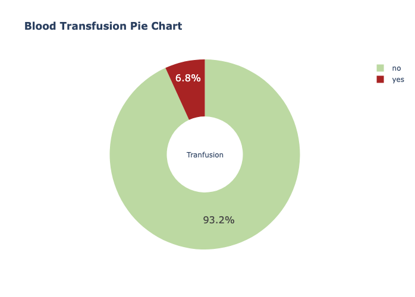

```python
type_ = ["no","yes"]
fig = make_subplots(rows =1,cols =1)

night_colour = ["#BCD9A2","#A82323"]
fig.add_trace(go.Pie(labels = type_ , values = df["needs_transfusion"].value_counts(), name = "Transfusion", marker_colors = night_colour ))

fig.update_traces(hole = 0.4,hoverinfo="label+percent+name",textfont_size = 16)

fig.update_layout(title_text="<b> Blood Transfusion Pie Chart <b>",
                 width = 500,
                 height = 500,
                annotations = [dict(text='Tranfusion',x=0.5,y=0.5,showarrow = False)])
fig.show()
```

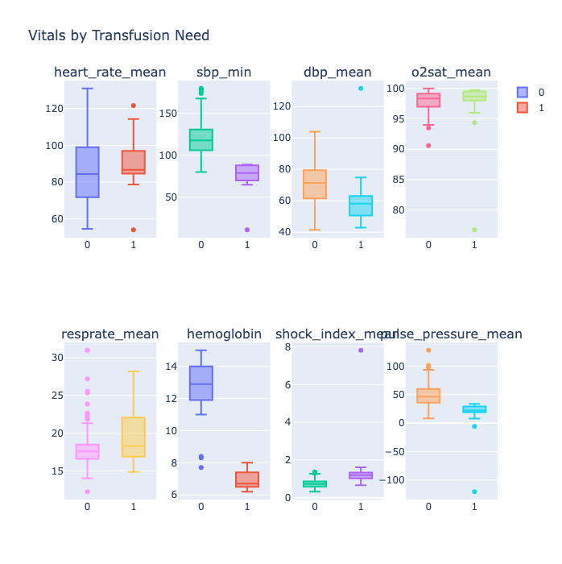

```python
cols = ['heart_rate_mean', 'sbp_min', 'dbp_mean', 'o2sat_mean', 'resprate_mean', 'hemoglobin', 'shock_index_mean', 'pulse_pressure_mean']
fig = make_subplots(rows=2, cols=4, subplot_titles=cols)

for i, col in enumerate(cols):
    row = i // 4 + 1
    col_pos = i % 4 + 1
    for outcome in [0, 1]:
        fig.add_trace(
            go.Box(y=df[df['needs_transfusion']==outcome][col], name=str(outcome), showlegend=(i==0)),
            row=row, col=col_pos
        )

fig.update_layout(height=700, title_text="Vitals by Transfusion Need")
fig.show()
```

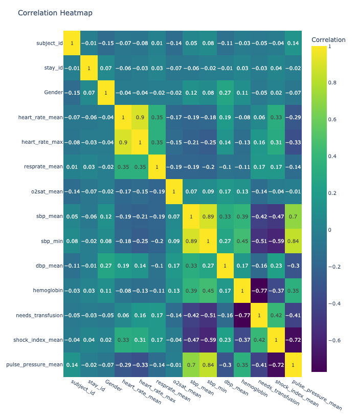

```python
import plotly.express as px

corr = df.corr(numeric_only=True).round(2)

fig = px.imshow(
    corr,
    text_auto=True,           # shows numbers on each cell
    color_continuous_scale='Viridis',
    aspect='auto',
    labels=dict(color='Correlation')
)

fig.update_layout(
    width=800,
    height=800,
    font=dict(size=10),       # shrink font so numbers fit in cells
    title='Correlation Heatmap'
)

fig.update_traces(textfont_size=10)  # controls the number size inside cells specifically

fig.show()
```

```python
print(df[["heart_rate_mean","resprate_mean","o2sat_mean","sbp_min","dbp_mean"]].describe())
```

```
       heart_rate_mean  resprate_mean  o2sat_mean     sbp_min    dbp_mean
count       206.000000     206.000000  206.000000  206.000000  206.000000
mean         86.670010      18.112986   97.897912  116.946602   70.060693
std          17.100514       2.576538    2.185874   22.862304   13.077913
min          53.954545      12.250000   76.750000   11.000000   41.500000
25%          72.450000      16.666667   97.000000  104.000000   60.333333
50%          85.500000      17.666667   98.333333  116.000000   70.900000
75%          98.916667      18.666667   99.160714  129.000000   78.821429
max         131.000000      31.000000  100.000000  180.000000  131.500000
```

```python
df.groupby('Gender')['needs_transfusion'].mean()
```

```
Gender
0    0.078947
1    0.054348
Name: needs_transfusion, dtype: float64
```

## Handling Class Imbalance

`needs_transfusion` is rare (14 positive cases out of 206 rows, ~6.8%). SMOTE generates synthetic minority-class examples by interpolating between real positive cases, so the model isn't incentivized to just predict the majority class for every row.

**Important:** SMOTE is applied *inside* the cross-validation pipeline (`imblearn.pipeline.Pipeline`), not once on the whole dataset beforehand. Applying it before splitting would let synthetic points generated from training-fold data leak into test folds — the same category of mistake as the label leakage above, just relocated into the evaluation step.

The model can learn who needs tranfusion only set by those 14 real examples only, it dosn't matter how many synethetic points we get generated from them.

```python
columns_to_drop = [
    'needs_transfusion', 'stay_id', 'subject_id',
    'hemoglobin', 'sbp_min', 'heart_rate_max',      # directly in the label formula
    'shock_index_mean', 'pulse_pressure_mean'        # derived from sbp_min, so still leaky
]
X = df.drop(columns=columns_to_drop, errors='ignore')
Y = df['needs_transfusion']
print(X.columns.tolist())
```

```
['Gender', 'heart_rate_mean', 'resprate_mean', 'o2sat_mean', 'sbp_mean', 'dbp_mean']
```

## Cross-Validation

A single 80/20 train/test split proved unreliable here — with only 14 positive cases total, one particular split can land 2-3 (or even 0-1) positive cases in the test set, making any single score highly sensitive to which rows happened to land where.

`StratifiedKFold(n_splits=5)` is used instead: the data is divided into 5 folds, each preserving the same ~6.8% positive rate, and every row is used as test data exactly once across the 5 rounds. Reporting the **mean and standard deviation** across folds (rather than a single number) makes the uncertainty in this estimate explicit, which matters given the small sample size.

```python
cv = StratifiedKFold(n_splits = 5, shuffle = True, random_state = 42)

rf_pipeline = ImbPipeline([('smote',SMOTE(random_state = 42, k_neighbors = 3)),
                           ('model',RandomForestClassifier(n_estimators=300, max_depth=5, random_state=42,n_jobs=-1))
                          ])
```

```python
rf_scores = cross_val_score(rf_pipeline,X,Y, cv = cv, scoring= 'roc_auc')
print("Per-fold ROC-AUC", np.round(rf_scores,3))
print(f"Mean:{rf_scores.mean():.3f} ± Std: {rf_scores.std():3f}")
```

```
Per-fold ROC-AUC [0.752 0.833 0.798 0.693 0.877]
Mean:0.791 ± Std: 0.063861
```

```python
oof_proba = cross_val_predict(rf_pipeline,X,Y,cv=cv,method='predict_proba')[:,1]

results_oof = pd.DataFrame({'actual': Y.values, 'predicted_proba':oof_proba})
print(results_oof.sort_values('predicted_proba', ascending=False).head(20))
```

```
     actual  predicted_proba
20        0         0.924805
59        0         0.902873
62        0         0.898920
37        0         0.872409
86        0         0.798707
15        0         0.740705
93        1         0.737939
38        0         0.726643
35        1         0.721395
33        1         0.699684
24        0         0.687717
4         0         0.672714
92        0         0.653069
108       0         0.647888
172       0         0.630537
184       0         0.627969
94        0         0.626095
113       1         0.618722
23        0         0.615203
5         0         0.592275
```

''' This is a demo data the majority of classes where classified as not in a need of tranfusion so the accuracy of the model will be very high so we wont be using that as a feild for classification report'''

## Model Comparison: Random Forest vs. Logistic Regression

Logistic Regression is included as an interpretable baseline. With this little data, a simpler model with fewer parameters can generalize better than a more flexible one — Random Forest has more room to fit noise in the training folds, while Logistic Regression's simplicity acts as a form of regularization almost by construction. Both models are evaluated on the *same* 5 folds (same `cv` object passed to both), so any difference in score reflects the models themselves, not random variation in how the data was split.

```python
# cv already defined

logreg_pipeline = ImbPipeline([('smote',SMOTE(random_state=42, k_neighbors = 3)),
                              ('model',LogisticRegression(max_iter=1000,random_state=42))
                              ])
```

```python
logreg_scores = cross_val_score(logreg_pipeline, X, Y, cv=cv, scoring='roc_auc')
print("Per-fold ROC-AUC:", np.round(logreg_scores, 3))
print(f"Mean: {logreg_scores.mean():.3f}  ±  Std: {logreg_scores.std():.3f}")
```

```
Per-fold ROC-AUC: [0.479 0.782 0.93  0.895 0.974]
Mean: 0.812  ±  Std: 0.178
```

**Model comparison (cross-validated, 5 folds):**

| Model | Mean ROC-AUC | Std | Notes |
| --- | --- | --- | --- |
| Random Forest (+ SMOTE) | `0.791` | `0.063` | Non-monotonic on heart rate (see findings) |
| Logistic Regression (+ SMOTE) | `0.812` | `0.178` | Interpretable baseline; matched or outperformed RF |

## Threshold Selection and Calibration

The default 0.5 classification threshold isn't assumed to be correct. Instead, a precision-recall curve is used to choose a threshold deliberately: for a transfusion-need screening use case, missing a real positive case (false negative) is arguably costlier than an unnecessary follow-up check (false positive), so a threshold favoring recall is a defensible, explicit choice — not the default.

A calibration curve checks whether predicted probabilities are trustworthy in their own right (e.g. does "70% predicted risk" really correspond to about 70% of such cases being positive). With only 14 positive cases, expect this curve to look noisy rather than a smooth diagonal — that's an honest reflection of the sample size, not a modeling error.

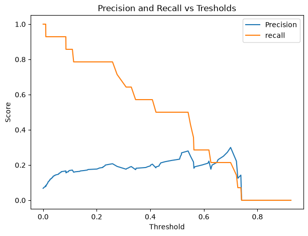

```
Thresholds for >= 0.8 recall: 0.109
At that threshold — precision: 0.171, recall: 0.857
```

```python
precision , recall, thresholds = precision_recall_curve(Y,oof_proba)

plt.figure(figsize=(7,5))
plt.plot(thresholds, precision[:-1], label = 'Precision')
plt.plot(thresholds, recall[:-1], label = 'recall')
plt.xlabel('Threshold')
plt.ylabel('Score')
plt.title('Precision and Recall vs Tresholds')
plt.legend()
plt.show()

target_recall = 0.8
idx = np.where(recall >= target_recall)[0][-1]

print(f"Thresholds for >= {target_recall} recall: {thresholds[idx]:.3f}")
print(f"At that threshold — precision: {precision[idx]:.3f}, recall: {recall[idx]:.3f}")
```

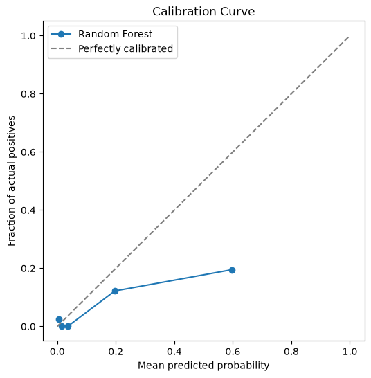

```python
rac_pos, mean_pred = calibration_curve(Y, oof_proba, n_bins=5, strategy='quantile')

plt.figure(figsize=(6,6))
plt.plot(mean_pred, rac_pos, marker='o', label='Random Forest')
plt.plot([0,1],[0,1], linestyle='--', color='gray', label='Perfectly calibrated')
plt.xlabel('Mean predicted probability')
plt.ylabel('Fraction of actual positives')
plt.title('Calibration Curve')
plt.legend()
plt.show()
```

## Final Model and Deployment

Cross-validation is used for *evaluating* the model honestly — not for producing the final deployed model. The final model is refit on the entire available dataset (all 206 rows, SMOTE-balanced), since more training data is better once evaluation is complete. This final model is exported to JavaScript via `m2cgen`, allowing it to run entirely client-side in the accompanying interactive demo (`transfusion_dashboard.html`) with no server or API required.

```python
final_model = RandomForestClassifier(n_estimators=300, max_depth=5, random_state=42)
sm_final = SMOTE(random_state=42, k_neighbors=3)
X_res, Y_res = sm_final.fit_resample(X, Y)
final_model.fit(X_res, Y_res)

print("Features model expects:", final_model.feature_names_in_)

code = m2c.export_to_javascript(final_model)
with open("model.js", "w") as f:
    f.write(code)
```

```
Features model expects: ['Gender' 'heart_rate_mean' 'resprate_mean' 'o2sat_mean' 'sbp_mean'
 'dbp_mean']
```

## Limitations

- **Sample size.** 206 patient stays and 14 positive cases is small; all metrics here should be read as indicative, not definitive. Cross-validation standard deviations reflect this directly.
- **Synthetic label.** `needs_transfusion` is rule-derived for this demo, not a real clinical outcome — this project demonstrates a leakage-aware, honestly evaluated ML methodology, not a validated clinical tool.
- **No additional real data was available** for this iteration. A larger patient sample would likely improve reliability more than further modeling changes.
- **Age** is collected in the interactive demo for context but is not one of the model's trained features.